# Part I - Ford GoBike Data Exploration

## Introduction

> This data set includes information about individual rides made in a bike-sharing system covering the greater San Francisco Bay area. Ford GoBike consists of a fleet of specially designed, sturdy and durable bikes that are locked into a network of docking stations throughout the city. The bikes can be unlocked from one station and returned to any other station in the system, making them ideal for one-way trips. The bikes are available for use 24 hours/day, 7 days/week, 365 days/year and riders have access to all bikes in the network when they become a member or purchase a pass.

## Preliminary Wrangling

```python
# import all packages and set plots to be embedded inline
import numpy as np
import pandas as pd
import matplotlib.pyplot as plt
import seaborn as sb
import datetime as dt

%matplotlib inline
```

> Load in your dataset and describe its properties through the questions below. Try and motivate your exploration goals through this section.

```python
ford_bike = pd.read_csv('201902-fordgobike-tripdata.csv')

ford_bike.head()
```

|  | duration_sec | start_time | end_time | start_station_id | start_station_name | start_station_latitude | start_station_longitude | end_station_id | end_station_name | end_station_latitude | end_station_longitude | bike_id | user_type | member_birth_year | member_gender | bike_share_for_all_trip |
| --- | --- | --- | --- | --- | --- | --- | --- | --- | --- | --- | --- | --- | --- | --- | --- | --- |
| 0 | 52185 | 2019-02-28 17:32:10.1450 | 2019-03-01 08:01:55.9750 | 21.0 | Montgomery St BART Station (Market St at 2nd St) | 37.789625 | -122.400811 | 13.0 | Commercial St at Montgomery St | 37.794231 | -122.402923 | 4902 | Customer | 1984.0 | Male | No |
| 1 | 42521 | 2019-02-28 18:53:21.7890 | 2019-03-01 06:42:03.0560 | 23.0 | The Embarcadero at Steuart St | 37.791464 | -122.391034 | 81.0 | Berry St at 4th St | 37.775880 | -122.393170 | 2535 | Customer | NaN | NaN | No |
| 2 | 61854 | 2019-02-28 12:13:13.2180 | 2019-03-01 05:24:08.1460 | 86.0 | Market St at Dolores St | 37.769305 | -122.426826 | 3.0 | Powell St BART Station (Market St at 4th St) | 37.786375 | -122.404904 | 5905 | Customer | 1972.0 | Male | No |
| 3 | 36490 | 2019-02-28 17:54:26.0100 | 2019-03-01 04:02:36.8420 | 375.0 | Grove St at Masonic Ave | 37.774836 | -122.446546 | 70.0 | Central Ave at Fell St | 37.773311 | -122.444293 | 6638 | Subscriber | 1989.0 | Other | No |
| 4 | 1585 | 2019-02-28 23:54:18.5490 | 2019-03-01 00:20:44.0740 | 7.0 | Frank H Ogawa Plaza | 37.804562 | -122.271738 | 222.0 | 10th Ave at E 15th St | 37.792714 | -122.248780 | 4898 | Subscriber | 1974.0 | Male | Yes |

## Wrangling

```python
ford_bike.info()
```

```
<class 'pandas.core.frame.DataFrame'>
RangeIndex: 183412 entries, 0 to 183411
Data columns (total 16 columns):
 #   Column                   Non-Null Count   Dtype
---  ------                   --------------   -----
 0   duration_sec             183412 non-null  int64
 1   start_time               183412 non-null  object
 2   end_time                 183412 non-null  object
 3   start_station_id         183215 non-null  float64
 4   start_station_name       183215 non-null  object
 5   start_station_latitude   183412 non-null  float64
 6   start_station_longitude  183412 non-null  float64
 7   end_station_id           183215 non-null  float64
 8   end_station_name         183215 non-null  object
 9   end_station_latitude     183412 non-null  float64
 10  end_station_longitude    183412 non-null  float64
 11  bike_id                  183412 non-null  int64
 12  user_type                183412 non-null  object
 13  member_birth_year        175147 non-null  float64
 14  member_gender            175147 non-null  object
 15  bike_share_for_all_trip  183412 non-null  object
dtypes: float64(7), int64(2), object(7)
memory usage: 22.4+ MB
```

```python
ford_bike.describe()
```

|  | duration_sec | start_station_id | start_station_latitude | start_station_longitude | end_station_id | end_station_latitude | end_station_longitude | bike_id | member_birth_year |
| --- | --- | --- | --- | --- | --- | --- | --- | --- | --- |
| count | 183412.000000 | 183215.000000 | 183412.000000 | 183412.000000 | 183215.000000 | 183412.000000 | 183412.000000 | 183412.000000 | 175147.000000 |
| mean | 726.078435 | 138.590427 | 37.771223 | -122.352664 | 136.249123 | 37.771427 | -122.352250 | 4472.906375 | 1984.806437 |
| std | 1794.389780 | 111.778864 | 0.099581 | 0.117097 | 111.515131 | 0.099490 | 0.116673 | 1664.383394 | 10.116689 |
| min | 61.000000 | 3.000000 | 37.317298 | -122.453704 | 3.000000 | 37.317298 | -122.453704 | 11.000000 | 1878.000000 |
| 25% | 325.000000 | 47.000000 | 37.770083 | -122.412408 | 44.000000 | 37.770407 | -122.411726 | 3777.000000 | 1980.000000 |
| 50% | 514.000000 | 104.000000 | 37.780760 | -122.398285 | 100.000000 | 37.781010 | -122.398279 | 4958.000000 | 1987.000000 |
| 75% | 796.000000 | 239.000000 | 37.797280 | -122.286533 | 235.000000 | 37.797320 | -122.288045 | 5502.000000 | 1992.000000 |
| max | 85444.000000 | 398.000000 | 37.880222 | -121.874119 | 398.000000 | 37.880222 | -121.874119 | 6645.000000 | 2001.000000 |

```python
ford_bike.shape
```

```
(183412, 16)
```

```python
ford_bike.columns
```

```
Index(['duration_sec', 'start_time', 'end_time', 'start_station_id',
       'start_station_name', 'start_station_latitude',
       'start_station_longitude', 'end_station_id', 'end_station_name',
       'end_station_latitude', 'end_station_longitude', 'bike_id', 'user_type',
       'member_birth_year', 'member_gender', 'bike_share_for_all_trip'],
      dtype='object')
```

```python
ford_bike.isnull().sum()
```

```
duration_sec                  0
start_time                    0
end_time                      0
start_station_id            197
start_station_name          197
start_station_latitude        0
start_station_longitude       0
end_station_id              197
end_station_name            197
end_station_latitude          0
end_station_longitude         0
bike_id                       0
user_type                     0
member_birth_year          8265
member_gender              8265
bike_share_for_all_trip       0
dtype: int64
```

```python
ford_bike['user_type'].value_counts()
```

```
Subscriber    163544
Customer       19868
Name: user_type, dtype: int64
```

```python
ford_bike.nunique()
```

```
duration_sec                 4752
start_time                 183401
end_time                   183397
start_station_id              329
start_station_name            329
start_station_latitude        334
start_station_longitude       335
end_station_id                329
end_station_name              329
end_station_latitude          335
end_station_longitude         335
bike_id                      4646
user_type                       2
member_birth_year              75
member_gender                   3
bike_share_for_all_trip         2
dtype: int64
```

```python
ford_bike['member_gender'].value_counts()
```

```
Male      130651
Female     40844
Other       3652
Name: member_gender, dtype: int64
```

```python
station = ford_bike['start_station_name'].value_counts()
station.head(5)
```

```
Market St at 10th St                                         3904
San Francisco Caltrain Station 2  (Townsend St at 4th St)    3544
Berry St at 4th St                                           3052
Montgomery St BART Station (Market St at 2nd St)             2895
Powell St BART Station (Market St at 4th St)                 2760
Name: start_station_name, dtype: int64
```

## Cleaning

### Inaccurate datatypes:

Convert start_time and end_time to date_time

```python
ford_bike['start_time'] = pd.to_datetime(ford_bike['start_time'])

ford_bike['end_time'] = pd.to_datetime(ford_bike['end_time'])
```

### Test

```python
ford_bike.info()
```

```
<class 'pandas.core.frame.DataFrame'>
RangeIndex: 183412 entries, 0 to 183411
Data columns (total 16 columns):
 #   Column                   Non-Null Count   Dtype
---  ------                   --------------   -----
 0   duration_sec             183412 non-null  int64
 1   start_time               183412 non-null  datetime64[ns]
 2   end_time                 183412 non-null  datetime64[ns]
 3   start_station_id         183215 non-null  float64
 4   start_station_name       183215 non-null  object
 5   start_station_latitude   183412 non-null  float64
 6   start_station_longitude  183412 non-null  float64
 7   end_station_id           183215 non-null  float64
 8   end_station_name         183215 non-null  object
 9   end_station_latitude     183412 non-null  float64
 10  end_station_longitude    183412 non-null  float64
 11  bike_id                  183412 non-null  int64
 12  user_type                183412 non-null  object
 13  member_birth_year        175147 non-null  float64
 14  member_gender            175147 non-null  object
 15  bike_share_for_all_trip  183412 non-null  object
dtypes: datetime64[ns](2), float64(7), int64(2), object(5)
memory usage: 22.4+ MB
```

```python
ford_bike.head()
```

|  | duration_sec | start_time | end_time | start_station_id | start_station_name | start_station_latitude | start_station_longitude | end_station_id | end_station_name | end_station_latitude | end_station_longitude | bike_id | user_type | member_birth_year | member_gender | bike_share_for_all_trip |
| --- | --- | --- | --- | --- | --- | --- | --- | --- | --- | --- | --- | --- | --- | --- | --- | --- |
| 0 | 52185 | 2019-02-28 17:32:10.145 | 2019-03-01 08:01:55.975 | 21.0 | Montgomery St BART Station (Market St at 2nd St) | 37.789625 | -122.400811 | 13.0 | Commercial St at Montgomery St | 37.794231 | -122.402923 | 4902 | Customer | 1984.0 | Male | No |
| 1 | 42521 | 2019-02-28 18:53:21.789 | 2019-03-01 06:42:03.056 | 23.0 | The Embarcadero at Steuart St | 37.791464 | -122.391034 | 81.0 | Berry St at 4th St | 37.775880 | -122.393170 | 2535 | Customer | NaN | NaN | No |
| 2 | 61854 | 2019-02-28 12:13:13.218 | 2019-03-01 05:24:08.146 | 86.0 | Market St at Dolores St | 37.769305 | -122.426826 | 3.0 | Powell St BART Station (Market St at 4th St) | 37.786375 | -122.404904 | 5905 | Customer | 1972.0 | Male | No |
| 3 | 36490 | 2019-02-28 17:54:26.010 | 2019-03-01 04:02:36.842 | 375.0 | Grove St at Masonic Ave | 37.774836 | -122.446546 | 70.0 | Central Ave at Fell St | 37.773311 | -122.444293 | 6638 | Subscriber | 1989.0 | Other | No |
| 4 | 1585 | 2019-02-28 23:54:18.549 | 2019-03-01 00:20:44.074 | 7.0 | Frank H Ogawa Plaza | 37.804562 | -122.271738 | 222.0 | 10th Ave at E 15th St | 37.792714 | -122.248780 | 4898 | Subscriber | 1974.0 | Male | Yes |

### Define

Drop rows with missing values

### Code

```python
ford_bike.dropna(inplace = True)
```

### Test

```python
ford_bike.isnull().any().sum()
```

```
0
```

```python
ford_bike.shape
```

```
(174952, 16)
```

### What is the structure of your dataset?

> There were 183412 observations with 16 columns in the dataset: ('duration_sec', 'start_time', 'end_time', 'start_station_name', 'start_station_id', 'start_station_latitude', 'start_station_longitude', 'end_station_id', 'end_station_name', 'end_station_latitude', 'end_station_longitude', 'bike_id', 'user_type','member_birth_year', 'member_gender', 'bike_share_for_all_trip'). 'User_type' and 'member_gender' columns have categorical values.

> The rows with null values have been removed, thus dataset is left with 174952 rows and 16 columns.

### What is/are the main feature(s) of interest in your dataset?

1. When are most trips taken in terms of time of day, day of the week, or month of the year?
2. How long does the average trip take?
3. Does the above depend on if a user is a subscriber or customer?

### What features in the dataset do you think will help support your investigation into your feature(s) of interest?

> start_time, end_time , User_type and member_gender

## Univariate Exploration

I'd extract the day and month from the start time column to create a different column

```python
# Extract  Start Day, Month, Hour
ford_bike['start_day'] = ford_bike['start_time'].dt.day_name()

ford_bike['start_months'] = ford_bike['start_time'].dt.month_name()

ford_bike['start_hour'] = ford_bike['start_time'].dt.hour

ford_bike.head(5)
```

|  | duration_sec | start_time | end_time | start_station_id | start_station_name | start_station_latitude | start_station_longitude | end_station_id | end_station_name | end_station_latitude | end_station_longitude | bike_id | user_type | member_birth_year | member_gender | bike_share_for_all_trip | start_day | start_months | start_hour |
| --- | --- | --- | --- | --- | --- | --- | --- | --- | --- | --- | --- | --- | --- | --- | --- | --- | --- | --- | --- |
| 0 | 52185 | 2019-02-28 17:32:10.145 | 2019-03-01 08:01:55.975 | 21.0 | Montgomery St BART Station (Market St at 2nd St) | 37.789625 | -122.400811 | 13.0 | Commercial St at Montgomery St | 37.794231 | -122.402923 | 4902 | Customer | 1984.0 | Male | No | Thursday | February | 17 |
| 2 | 61854 | 2019-02-28 12:13:13.218 | 2019-03-01 05:24:08.146 | 86.0 | Market St at Dolores St | 37.769305 | -122.426826 | 3.0 | Powell St BART Station (Market St at 4th St) | 37.786375 | -122.404904 | 5905 | Customer | 1972.0 | Male | No | Thursday | February | 12 |
| 3 | 36490 | 2019-02-28 17:54:26.010 | 2019-03-01 04:02:36.842 | 375.0 | Grove St at Masonic Ave | 37.774836 | -122.446546 | 70.0 | Central Ave at Fell St | 37.773311 | -122.444293 | 6638 | Subscriber | 1989.0 | Other | No | Thursday | February | 17 |
| 4 | 1585 | 2019-02-28 23:54:18.549 | 2019-03-01 00:20:44.074 | 7.0 | Frank H Ogawa Plaza | 37.804562 | -122.271738 | 222.0 | 10th Ave at E 15th St | 37.792714 | -122.248780 | 4898 | Subscriber | 1974.0 | Male | Yes | Thursday | February | 23 |
| 5 | 1793 | 2019-02-28 23:49:58.632 | 2019-03-01 00:19:51.760 | 93.0 | 4th St at Mission Bay Blvd S | 37.770407 | -122.391198 | 323.0 | Broadway at Kearny | 37.798014 | -122.405950 | 5200 | Subscriber | 1959.0 | Male | No | Thursday | February | 23 |

```python
# Extract  End Day, Month, Hour
ford_bike['End_day'] = ford_bike['end_time'].dt.day_name()

ford_bike['End_months'] = ford_bike['end_time'].dt.month_name()

ford_bike['End_hour'] = ford_bike['end_time'].dt.hour

ford_bike.head(2)
```

|  | duration_sec | start_time | end_time | start_station_id | start_station_name | start_station_latitude | start_station_longitude | end_station_id | end_station_name | end_station_latitude | ... | user_type | member_birth_year | member_gender | bike_share_for_all_trip | start_day | start_months | start_hour | End_day | End_months | End_hour |
| --- | --- | --- | --- | --- | --- | --- | --- | --- | --- | --- | --- | --- | --- | --- | --- | --- | --- | --- | --- | --- | --- |
| 0 | 52185 | 2019-02-28 17:32:10.145 | 2019-03-01 08:01:55.975 | 21.0 | Montgomery St BART Station (Market St at 2nd St) | 37.789625 | -122.400811 | 13.0 | Commercial St at Montgomery St | 37.794231 | ... | Customer | 1984.0 | Male | No | Thursday | February | 17 | Friday | March | 8 |
| 2 | 61854 | 2019-02-28 12:13:13.218 | 2019-03-01 05:24:08.146 | 86.0 | Market St at Dolores St | 37.769305 | -122.426826 | 3.0 | Powell St BART Station (Market St at 4th St) | 37.786375 | ... | Customer | 1972.0 | Male | No | Thursday | February | 12 | Friday | March | 5 |

2 rows × 22 columns

### User Type

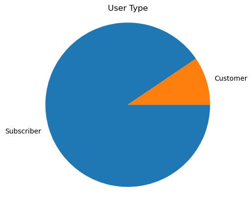

```python
Type = ford_bike['user_type'].value_counts()

plt.pie(Type, labels = Type.index, counterclock = False);
plt.title('User Type')
plt.axis('square');
```

The figure above depicts that Subscribers used the service the most as compared to external customers.

### Gender

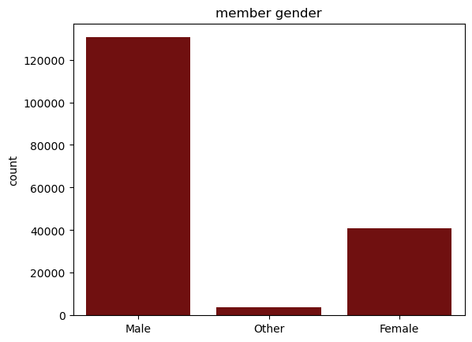

```python
sb.countplot(data=ford_bike, x="member_gender", color='maroon');
plt.xlabel("")
plt.title("member gender")
```

Most of the users are male

### Busiest Day in a Week

```python
ford_bike['start_day'].value_counts()
```

```
Thursday     33712
Tuesday      30584
Wednesday    28426
Friday       27663
Monday       25641
Sunday       14512
Saturday     14414
Name: start_day, dtype: int64
```

```python
# convert day, and hour into ordered categorical types
ordinal_var_dict = {'start_day': ['Monday','Tuesday','Wednesday','Thursday','Friday', 'Saturday', 'Sunday'],
                    'End_day': ['Monday','Tuesday','Wednesday','Thursday','Friday', 'Saturday', 'Sunday'],
                   }

for var in ordinal_var_dict:
    ordered_var = pd.api.types.CategoricalDtype(ordered = True,
                                                categories = ordinal_var_dict[var])
    ford_bike[var] = ford_bike[var].astype(ordered_var)
```

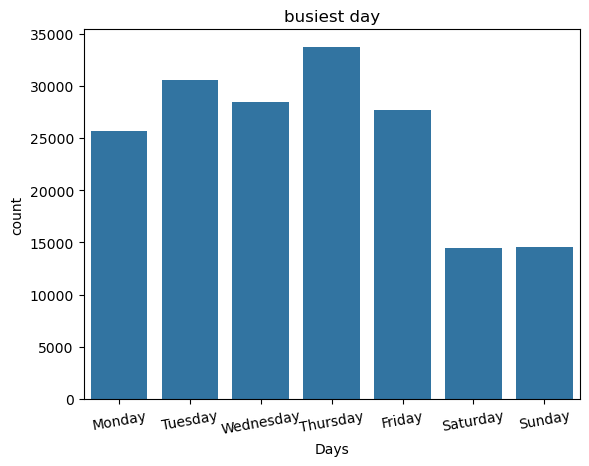

```python
c = sb.color_palette()[0]

sb.countplot(data = ford_bike, x='start_day', color=c)
plt.xlabel("Days")
plt.xlim()
plt.xticks(rotation = 10) #[0,1,2,3,4,5,6],["Mon","Tues","Wed","Thurs","Fri","Sat","Sun"]);
plt.title("busiest day");
```

The busiest days were Thursday and Tuesday. On the weekends, Sunday was slightly higher than Saturday.

### Busiest Hours in a Day

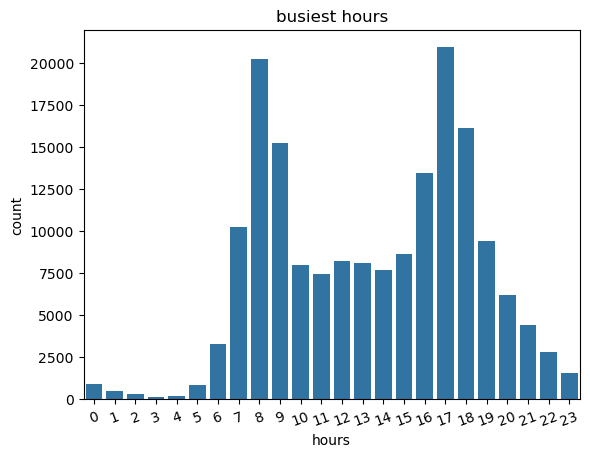

```python
sb.countplot(data=ford_bike, x='start_hour', color=c);
plt.title("busiest hours")
plt.xlabel("hours")
plt.xticks(rotation=20);
```

The busiest Start hours were 8am and 17:00pm; which were evidently rush hours as people either went to work or returned by that time.

### Longest Duration Travelled

```python
# longest distance travelled

ford_bike.sort_values(by='duration_sec', ascending=False ,axis=0, inplace=True)
ford_bike.head()
```

|  | duration_sec | start_time | end_time | start_station_id | start_station_name | start_station_latitude | start_station_longitude | end_station_id | end_station_name | end_station_latitude | ... | user_type | member_birth_year | member_gender | bike_share_for_all_trip | start_day | start_months | start_hour | End_day | End_months | End_hour |
| --- | --- | --- | --- | --- | --- | --- | --- | --- | --- | --- | --- | --- | --- | --- | --- | --- | --- | --- | --- | --- | --- |
| 85465 | 84548 | 2019-02-16 15:48:25.029 | 2019-02-17 15:17:33.080 | 3.0 | Powell St BART Station (Market St at 4th St) | 37.786375 | -122.404904 | 368.0 | Myrtle St at Polk St | 37.785434 | ... | Subscriber | 1981.0 | Male | No | Saturday | February | 15 | Sunday | February | 15 |
| 127999 | 83519 | 2019-02-09 15:16:17.537 | 2019-02-10 14:28:17.270 | 72.0 | Page St at Scott St | 37.772406 | -122.435650 | 43.0 | San Francisco Public Library (Grove St at Hyde... | 37.778768 | ... | Customer | 1990.0 | Male | No | Saturday | February | 15 | Sunday | February | 14 |
| 112435 | 83407 | 2019-02-11 16:25:33.069 | 2019-02-12 15:35:40.956 | 77.0 | 11th St at Natoma St | 37.773507 | -122.416040 | 344.0 | 16th St Depot | 37.766349 | ... | Customer | 1988.0 | Male | No | Monday | February | 16 | Tuesday | February | 15 |
| 5203 | 83195 | 2019-02-27 14:47:23.181 | 2019-02-28 13:53:58.433 | 243.0 | Bancroft Way at College Ave | 37.869360 | -122.254337 | 248.0 | Telegraph Ave at Ashby Ave | 37.855956 | ... | Subscriber | 1962.0 | Female | Yes | Wednesday | February | 14 | Thursday | February | 13 |
| 95750 | 82512 | 2019-02-14 13:56:21.728 | 2019-02-15 12:51:34.315 | 368.0 | Myrtle St at Polk St | 37.785434 | -122.419622 | 44.0 | Civic Center/UN Plaza BART Station (Market St ... | 37.781074 | ... | Customer | 1998.0 | Other | No | Thursday | February | 13 | Friday | February | 12 |

5 rows × 22 columns

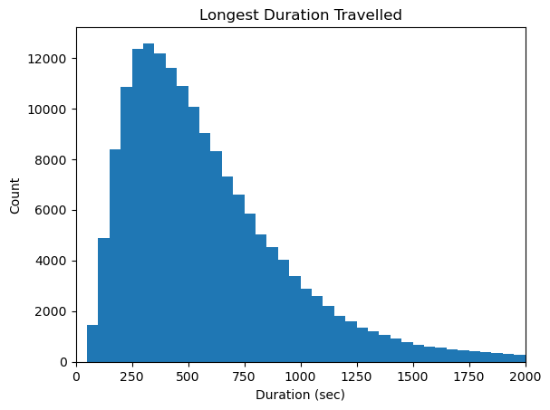

```python
def plot_hist(data, x, x_label, y_label, title, bin_size):
    #function for histogram plot
    bins = np.arange(50, data[x].max() + bin_size, bin_size)
    plt.hist(data=data, x = x, bins=bins)
    plt.xlabel(x_label)
    plt.ylabel(y_label)
    plt.title(title)
    plt.xlim([0, 2000]);

#scaled plot
plot_hist(data=ford_bike, x = 'duration_sec', x_label = 'Duration (sec)', y_label = 'Count',
          title = "Longest Duration Travelled", bin_size = 50);
```

### Month most trips ended

```python
ford_bike['End_months'].value_counts()
```

```
February    174938
March           14
Name: End_months, dtype: int64
```

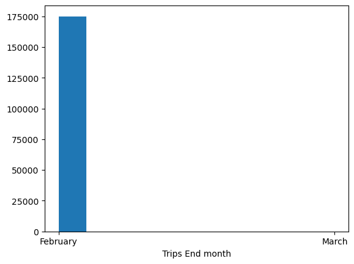

```python
plt.hist(data= ford_bike, x= 'End_months')
plt.xlabel('Trips End month');
```

From above, we see that above 95% of the trips started and also ended in February while very few ended in March.

### Bike Share Ratio

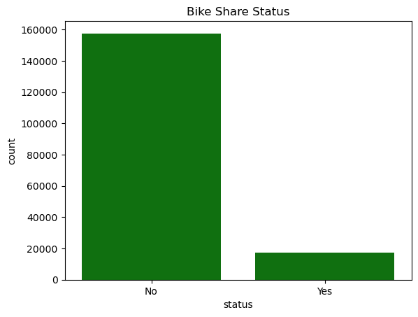

```python
#ford_bike['bike_share_for_all_trip'].value_counts()

sb.countplot(data=ford_bike, x='bike_share_for_all_trip', color='green');
plt.title("Bike Share Status")
plt.xlabel("status");
```

There were lesser Bike share in the dataset compared to the non-shared bike.

### Of the features you investigated, were there any unusual distributions? Did you perform any operations on the data to tidy, adjust, or change the form of the data? If so, why did you do this?

I dropped the null values that did not include necessary values for this visualization. Then I extracted the hour, day, month from the vailable data column.

## Bivariate Exploration

1. WeekDays vs duration
2. Hours vs User Type
3. weekday vs hours
4. gender vs user type
5. gender vs weekdays

### Days vs Duration

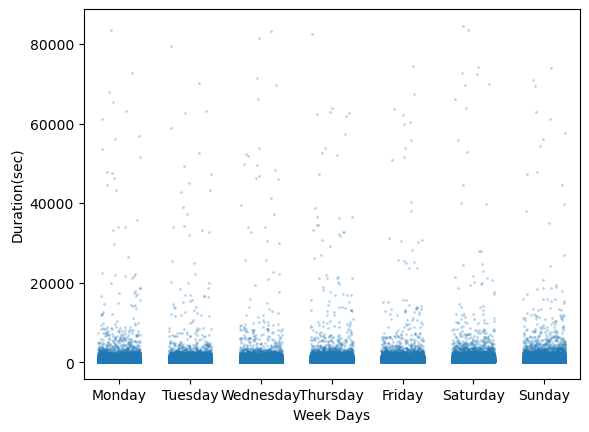

```python
sb.stripplot(data=ford_bike, x='start_day', y='duration_sec', alpha= 0.3, jitter= 0.3, s=2)
plt.xlabel('Week Days')
plt.ylabel('Duration(sec)')
#plt.xticks([0,1,2,3,4,5,6],["Mon","Tues","Wed","Thurs","Fri","Sat","Sun"]);
```

### User Type vs Gender

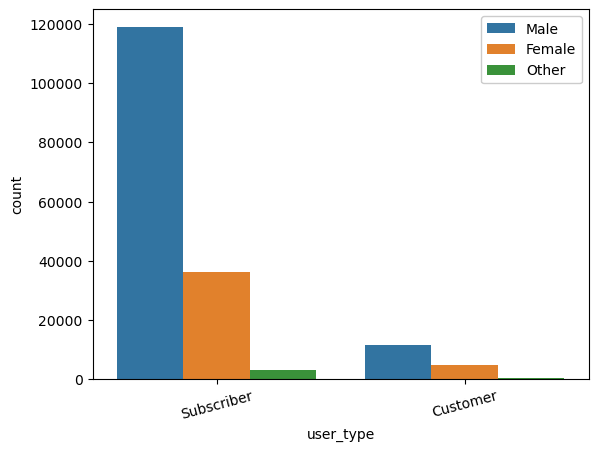

```python
ax = sb.countplot(data=ford_bike, x='user_type', hue='member_gender' )
ax.legend(loc = 1, framealpha = 1) # lower right, no transparency
plt.xticks(rotation = 15);
```

There were more Subscribers than Customers and the male users were higher than other genders

### Weekday vs Hour

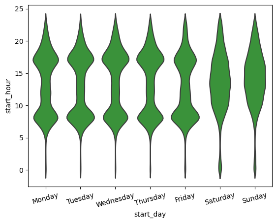

```python
base_color = sb.color_palette()[2]

sb.violinplot(data=ford_bike, x='start_day', y='start_hour', color=base_color, inner=None)
plt.xticks(rotation=15); #[0,1,2,3,4,5,6],["Mon","Tues","Wed","Thurs","Fri","Sat","Sun"]);
```

The plot above shows that there were more usage on weekdays between 8-9am when most commuters must have used tit to get to work and 17:00(5pm) when they returned from work. While on the weekends, the trend was different and was at its peak during the afternoon hours.

### Gender vs WeekDays

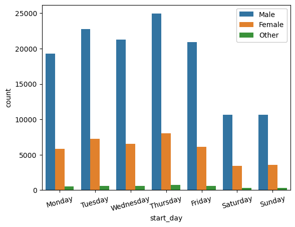

```python
ax = sb.countplot(data=ford_bike, x='start_day', hue='member_gender' )
ax.legend(loc = 1, framealpha = 1) # lower right, no transparency
plt.xticks(rotation = 15); #[0,1,2,3,4,5,6],["Mon","Tues","Wed","Thurs","Fri","Sat","Sun"],
```

There were more people on the weekdays than the weekends. Thursday had the highest usage while Saturday and Sunday had teh least.

### Hourly Usage Per USer Type

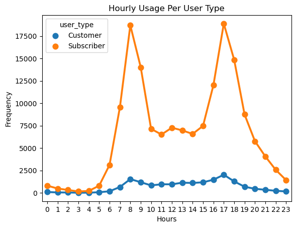

```python
df = ford_bike.groupby(["start_hour", "user_type"]).size().reset_index()


#plotting
sb.pointplot(data = df, x="start_hour", hue="user_type", y=0)
plt.title("Hourly Usage Per User Type")
plt.xlabel("Hours")
plt.ylabel("Frequency");
```

8am and 17:00pm had a surge, probably as more people closed from the days job that period.

### Talk about some of the relationships you observed in this part of the investigation. How did the feature(s) of interest vary with other features in the dataset?

1. There was higher hourly usage amongst subscribers than customers.
2. Males had a higher representation in the data.
3. the distribution of the weekend trips was distributed evenly not concentrated within specific periods.

### Did you observe any interesting relationships between the other features (not the main feature(s) of interest)?

The weekdays and the duration travelled.

## Multivariate Exploration

### Weekly Average Trip

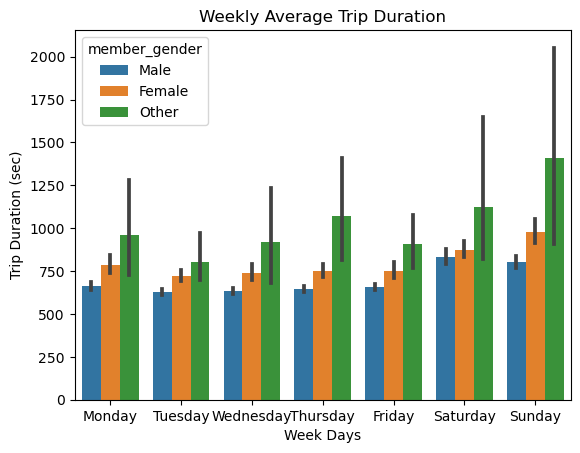

```python
ax = sb.barplot(data = ford_bike, x='start_day', y='duration_sec', hue='member_gender')
#plt.xticks([0,1,2,3,4,5,6], ["Mon","Tues","Wed","Thurs","Fri","Sat","Sun"])
plt.xlabel('Week Days')
plt.ylabel('Trip Duration (sec)')
plt.title('Weekly Average Trip Duration');
```

On the average, the average trip duration for Sunday was longest by the Gender "Other".

### Average Trip Duration

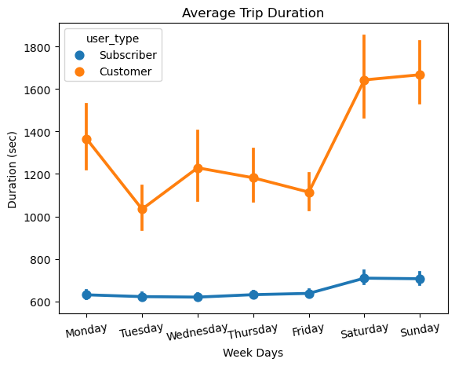

```python
ax = sb.pointplot(data = ford_bike, x='start_day' , y='duration_sec', hue='user_type')
plt.xticks(rotation=10) #[0,1,2,3,4,5,6], ["Mon","Tues","Wed","Thurs","Fri","Sat","Sun"],
plt.xlabel('Week Days')
plt.ylabel('Duration (sec)')
plt.title('Average Trip Duration');
```

### Trip Duration vs Gender and Customer Type

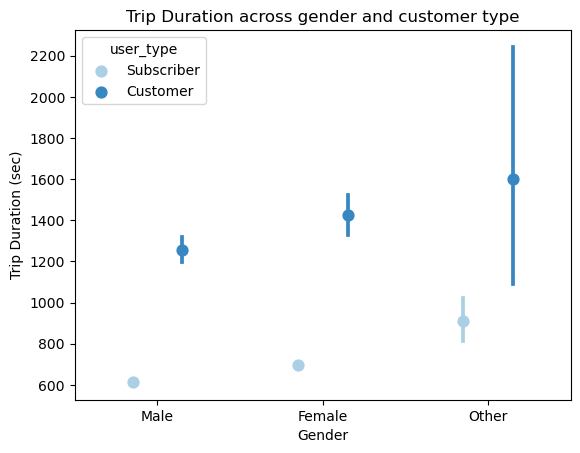

```python
#pointplot
ax = sb.pointplot(data = ford_bike, x ='member_gender', y = 'duration_sec', hue = 'user_type',
           palette = 'Blues', linestyles = '', dodge = 0.3)
plt.title('Trip Duration across gender and customer type')
plt.ylabel('Trip Duration (sec)')
plt.xlabel('Gender')
ax.set_yticklabels([], minor = True)
plt.show();
```

The Customers from the 'other' gender spent the most time on their trips. Males are seen to spend the least duration.

### Talk about some of the relationships you observed in this part of the investigation. Were there features that strengthened each other in terms of looking at your feature(s) of interest?

I observed that despite the subscribers using the service more than customers, the Customers travelled for longer durations on the average.

### Were there any interesting or surprising interactions between features?

It seemed that depite the "other" gender been least represented, they had a higher weekly trip duration by gender.

## Conclusions

These clearly shows that FordGo rented out more bikes on weekdays to users, and fewer rentals on the weekend. However, these users drove longer distances on the weekend as compared to the weekdays where they just drove to destination and returned them to the closest station.